# STATS 326/786

Week 4 Tutorial

# Problem 1

> Below is some fake seasonal data (with a perfectly periodic pattern) with no trend and no remainder components. In class, we learned that moving averages are useful for smoothing time series. Compute a $2 \times 4~\text{MA}$ and a $5~\text{MA}$ and overlay these on the original time series. What do you notice, and why is this happening?

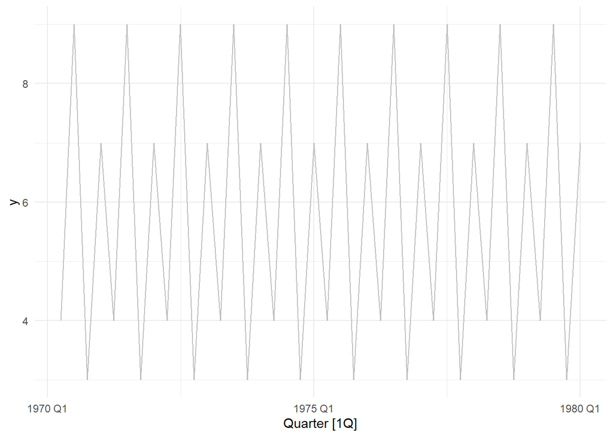

```r
data <- tsibble(Quarter = yearquarter(1:40),
                y = rep(c(4, 9, 3, 7), 10),
                index = Quarter)

data %>%
  autoplot(y, colour = "grey") +
  theme_minimal()
```

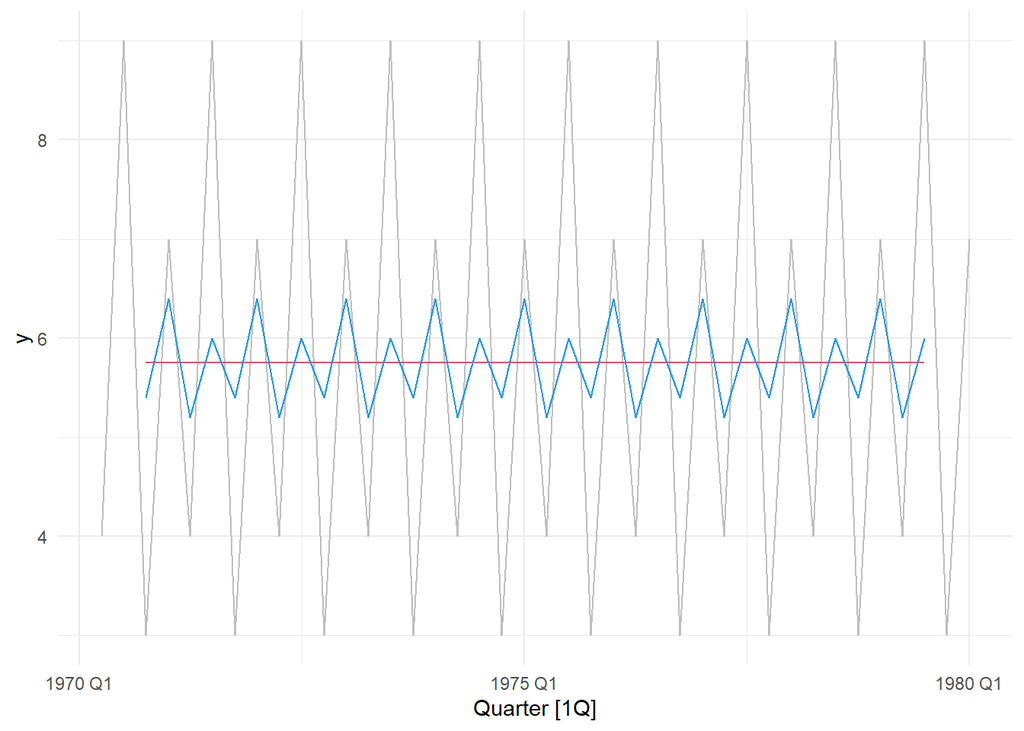

```r
data.ma <- data %>%
  mutate(`4-MA` = slider::slide_dbl(y,
                                    mean,
                                    .before = 1,
                                    .after = 2,
                                    .complete = TRUE),
         `2x4-MA` = slider::slide_dbl(`4-MA`,
                                      mean,
                                      .before = 1,
                                      .after = 0,
                                      .complete = TRUE),
         `5-MA` = slider::slide_dbl(y,
                                    mean,
                                    .before = 2,
                                    .after = 2,
                                    .complete = TRUE))

data.ma %>%
  autoplot(y, colour = "grey") +
  autolayer(data.ma, `2x4-MA`, col = 2) +
  autolayer(data.ma, `5-MA`, col = 4) +
  theme_minimal()
```

The time series is perfectly periodic, with a fixed seasonal pattern. The $4 ~ \text{MA}$ takes an average of $(y_{t-1}, y_t, y_{t+1}, y_{t+2})$ for each $t$. This will be the same number (the mean of the time series) for each $t$ because the seasonal pattern repeats perfectly. Then applying a $2~ \text{MA}$ to this gives the same result because the average of a constant is that constant (but with the added property of symmetry around each time point). Therefore the $2\times 4~\text{MA}$ has removed the seasonal fluctuations.

However, if we apply a $5 ~ \text{MA}$ to the data, then $(y_{t-2}, y_{t-1}, y_t, y_{t+1}, y_{t+2})$ each have equal weight ($\frac{1}{5}$) in the moving-averaged time series at time $t$. Notice that for quarterly data, both $y_{t-2}$ and $y_{t+2}$ will be the same quarter in different years, meaning that that season has a combined contribution of 40% weight to the moving averaged time series at time $t$, which is larger than any other season. Compare this to a $2\times 4~\text{MA}$, $y_{t-2}$ and $y_{t+2}$ each contribute $\frac{1}{8}$ to the weight for a combined weight of 25% (equal with the other three seasons). Therefore, the $5 ~ \text{MA}$ does not remove the seasonal fluctuations.

> Repeat the above exercise, but for the fake data below. This data is seasonal (again, with a perfectly periodic pattern) with a linear trend and no remainder component.

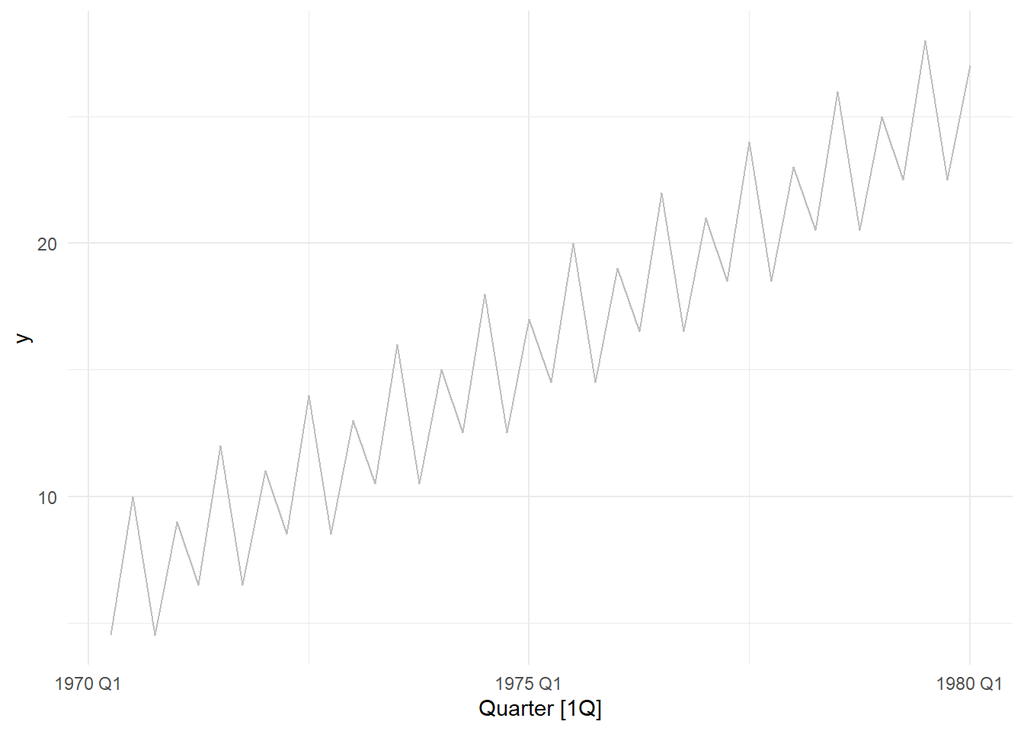

```r
data <- tsibble(Quarter = yearquarter(1:40),
                y = rep(c(4, 9, 3, 7), 10) + 0.5 * 1:40,
                index = Quarter)


data %>%
  autoplot(y, colour = "grey") +
  theme_minimal()
```

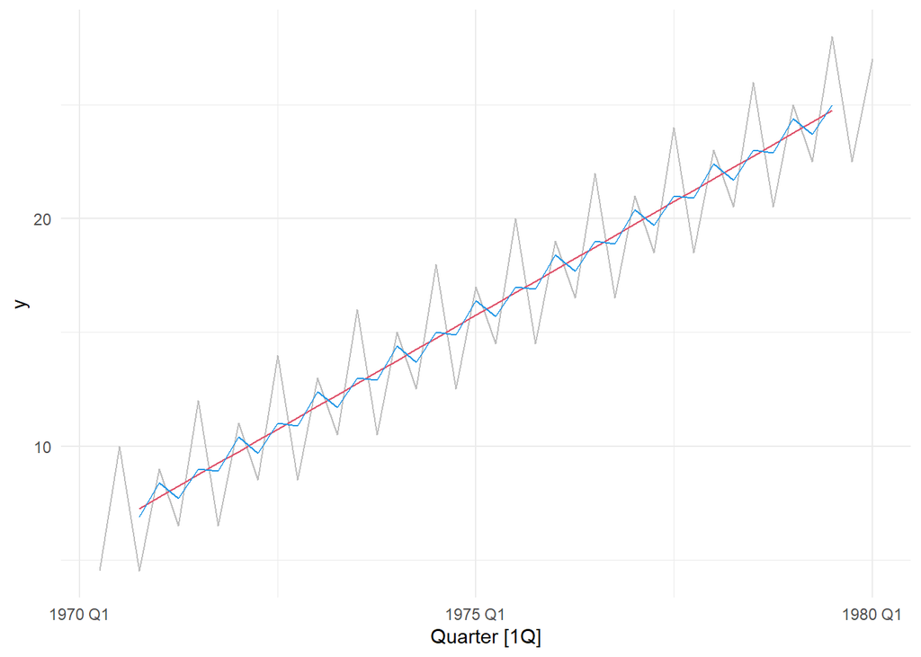

```r
data.ma <- data %>%
  mutate(`4-MA` = slider::slide_dbl(y,
                                    mean,
                                    .before = 1,
                                    .after = 2,
                                    .complete = TRUE),
         `2x4-MA` = slider::slide_dbl(`4-MA`,
                                      mean,
                                      .before = 1,
                                      .after = 0,
                                      .complete = TRUE),
         `5-MA` = slider::slide_dbl(y,
                                    mean,
                                    .before = 2,
                                    .after = 2,
                                    .complete = TRUE))

data.ma %>%
  autoplot(y, colour = "grey") +
  autolayer(data.ma, `2x4-MA`, col = 2) +
  autolayer(data.ma, `5-MA`, col = 4) +
  theme_minimal()
```

We can notice a similar pattern as in the previous question, but now the $2\times 4~\text{MA}$ time series is perfectly linear (the seasonal variation has been removed and we only see the remaining trend). The $5~\text{MA}$ doesn’t remove all of the seasonal variation for the same reasons as before.

> If you were to apply a $3 \times 5~\text{MA}$ to a time series, analytically derive the weights that each observation contributes to the moving-averaged time series at time $t$.

Solution:

Let $y_t$ be a time series with index $t$. First apply a $5~\text{MA}$ to this series, noting that this is a symmetric order. We get:
$$\begin{equation*}
x_t = \frac{1}{5} y_{t-2} + \frac{1}{5} y_{t-1} + \frac{1}{5} y_t + \frac{1}{5} y_{t+1} + \frac{1}{5} y_{t+2}.
\end{equation*}$$
Then applying a $3~\text{MA}$ to $x_t$, we get:
$$\begin{eqnarray*}
x^{'}_t &=& \frac{1}{3} x_{t-1} + \frac{1}{3} x_t + \frac{1}{3} x_{t+1} \\
&=& \frac{1}{15} y_{t-3} + \frac{2}{15} y_{t-2} + \frac{1}{5} y_{t-1} + \frac{1}{5} y_{t} + \frac{1}{5} y_{t+1} + \frac{2}{15} y_{t+2} + \frac{1}{15} y_{t+3}.
\end{eqnarray*}$$
This is also symmetric around time $t$. Notice that the weights are higher closer to $t$ and smaller further away from $t$.

# Problem 2

> Below is an example of a time series with multiplicative seasonality. In this problem, you learn how to perform your own (multiplicative) classical decomposition from first principles.

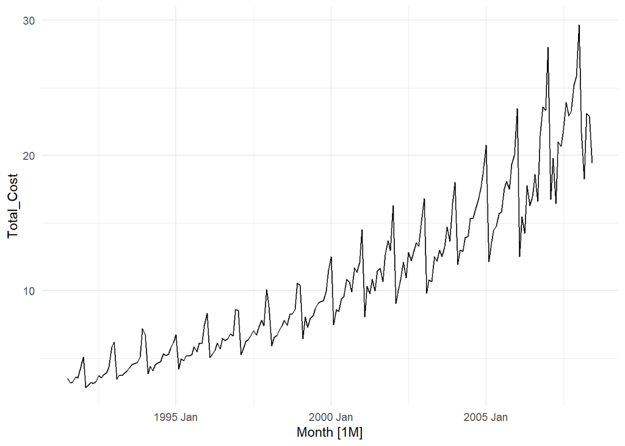

```r
a10 <- PBS %>%
  filter(ATC2 == "A10") %>%
  select(Month, Concession, Type, Cost) %>%
  summarise(Total_Cost = sum(Cost)) %>%
  mutate(Total_Cost = Total_Cost / 1e6,
         Month.Name = month(Month, label = TRUE))

a10 %>%
  autoplot(Total_Cost) +
  theme_minimal()
```

> Calculate the trend-cycle by performing a $2\times 12~\text{MA}$ on your time series.

```r
a10 <- a10 %>%
  mutate(`12-MA` = slider::slide_dbl(Total_Cost,
                                     mean,
                                     .before = 5,
                                     .after = 6,
                                     .complete = TRUE),
         Trend = slider::slide_dbl(`12-MA`,
                                   mean,
                                   .before = 1,
                                   .after = 0,
                                   .complete = TRUE))
```

> Compute the detrended time series (original time series divided by trend).

```r
a10 <- a10 %>%
  mutate(Detrended = Total_Cost / Trend)
```

> Calculate the seasonal factor for each month (noting that these must sum to 12 for a monthly time series).

```r
a10.s <- a10 %>%
  index_by(Month.Name) %>%
  summarise(Seasonal = mean(Detrended, na.rm = TRUE))

# Check what these sum to.  If not 12, adjust for this
sum.s <- a10.s %>% pull(Seasonal) %>% sum()

# Adjust the seasonal factors such that they sum to 12
a10.s <- a10.s %>%
  mutate(Seasonal = Seasonal / sum.s * 12)
```

> Merge your data sets so the seasonal factor is now included in your original tsibble.

```r
a10 <- a10 %>%
  left_join(a10.s, by = "Month.Name")
```

> Compute the remainder component (as detrended divided by seasonal) and seasonally-adjusted component (as original time series divided by seasonal).

```r
a10 <- a10 %>%
  mutate(Remainder = Detrended / Seasonal,
         Sadj = Total_Cost / Seasonal)
```

> Plot the original time series and overlay it with the trend-cycle and seasonally-adjusted series.

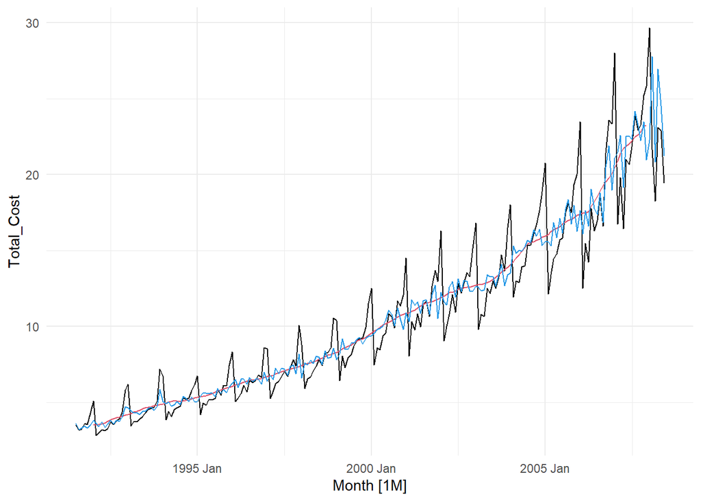

```r
a10 %>%
  autoplot(Total_Cost) +
  autolayer(a10, Trend, col = 2) +
  autolayer(a10, Sadj, col = 4) +
  theme_minimal()
```

> Extra: See if you can re-create the classical decomposition plot.

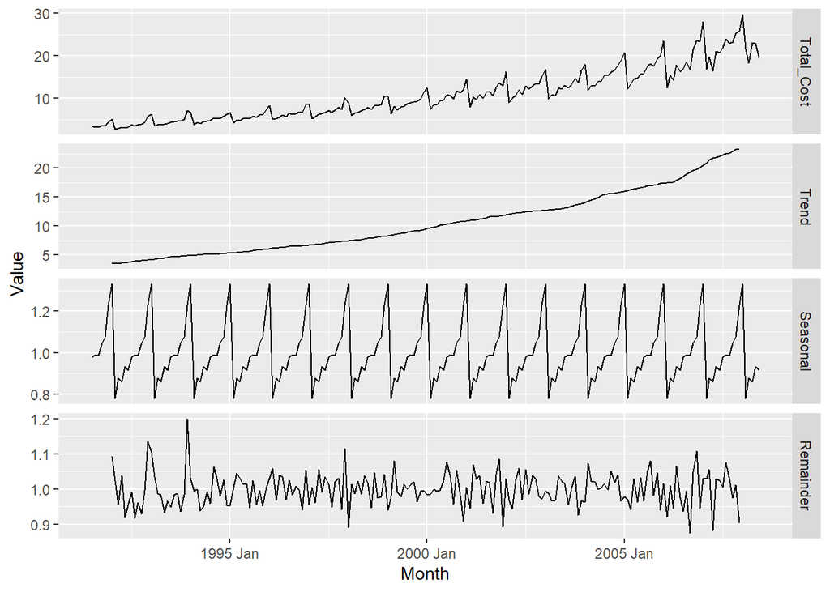

```r
# Pivot the data set
a10.longer <- a10 %>%
  pivot_longer(cols = c(Total_Cost, Trend, Seasonal, Remainder),
               names_to = "Series",
               values_to = "Value")

# Plot (note that factor order needs to be specified to order the facets)
ggplot(data = a10.longer,
       mapping = aes(x = Month,
                     y = Value)) +
  geom_line() +
  facet_grid(rows = vars(factor(Series, levels =
                                  c("Total_Cost", "Trend",
                                    "Seasonal", "Remainder"))),
             scales = "free_y")
```

This is an attempt. It’s not a perfect replication, but it’s close enough. See if you can do any better by adding on the scale.